# Pop Gen - Problem Set 1

Mei Iwamoto

10/16/2024

Question 1: There would be ((m)(m+1))/2 possible genotypes.

Question 2: a: the estimated frequency of allele A1 is 143/240 = 0.596. b: probability of observing this outcome? chi-squared

```r
 (((96-90)^2)/90)+(((24-30)^2)/30)
```

```
## [1] 1.6
```

Question 3: graph central concept of Hardy-Weinberg. create a function for each line on the plot, use add=true to add all curves to the same plot

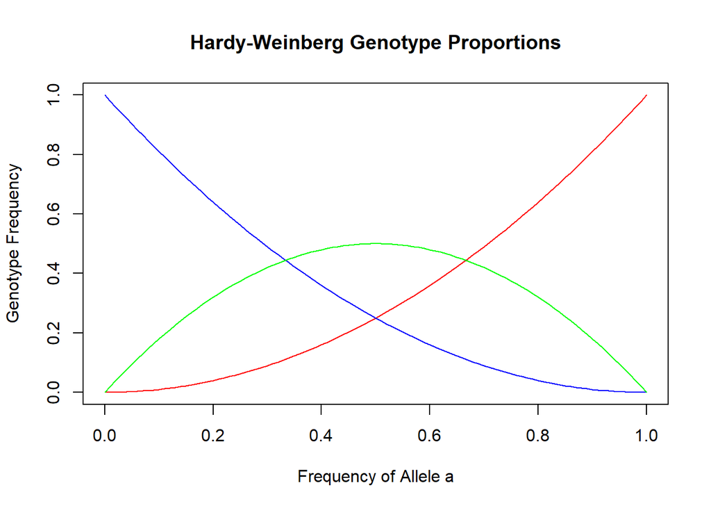

```r
fun <- function(x) (x^2)
fun1<- function(x) (1-x)^2
fun2 <- function(x) (2*x*(1-x))

curve(fun, col='red', xlab='Frequency of Allele a', ylab='Genotype Frequency', main='Hardy-Weinberg Genotype Proportions')
curve(fun1, col='blue', add=TRUE)
curve(fun2, col='green', add=TRUE)
```

The Hardy-Weinberg proportions relate to basic probability rules in that the proportions are the binomial expansion of (p+q)^2, where there are two successive events. With this expansion, we can do binomial probability calculations to determine the probability of each outcome - here this refers to p^2, 2pq, and q^2. And that is referring to the two homozygous genotypes and the one heterozygous genotype.

Question 4: test each population for hardy weinberg Population A, df=2

```r
(((78-50)^2)/50)+(((106-100)^2)/100)+(((16-50)^2)/50)
```

```
## [1] 39.16
```

The chi-squared value for p=0.05 is 10.597 for 2 degrees of freedom. Seeing as our calculated chi squared value is 39.16 and thus greater than 10.597, we could say that this population rejects the hypothesis of following Hardy Weinberg proportions.

Population B, df = 2

```r
(((29-50)^2)/50)+(((58-100)^2)/100)+(((13-50)^2)/50)
```

```
## [1] 53.84
```

Population B also is not following Hardy Weinberg proportions because it has a chi squared value of 53.84, which is greater than 10.597 (like Pop A) so our pvalue is less than 0.05 as well.

Population C, df = 2

```r
(((112-50)^2)/50)+(((32-100)^2)/100)+(((3-50)^2)/50)
```

```
## [1] 167.3
```

Population D, df = 2

```r
(((94-50)^2)/50)+(((70-100)^2)/100)+(((36-50)^2)/50)
```

```
## [1] 51.64
```

Question 5: genetic drift for 5 alleles, initial frequency = 0.5, pop sizes of 50, 100, 1000 Use sample to do the random genetic drift

```r
#rows for population, column for generation? pop size = 50, afreq will calculate frequency of allele a in the population over time (columns here for simulations)
a1 <- matrix(data = NA, nrow = 100, ncol = 100)
a2 <- matrix(data = NA, nrow = 100, ncol = 100)
a3 <- matrix(data = NA, nrow = 100, ncol = 100)
a4 <- matrix(data = NA, nrow = 100, ncol = 100)
a5 <- matrix(data = NA, nrow = 100, ncol = 100)

afreq <- matrix(data=NA, nrow=100, ncol=5)

sam <- matrix(data=NA, nrow=100, ncol=5)

for (m in 1:5) {
  sam[1:100, m] <- sample(c("a","A"), size = 100, replace=T, prob=c(0.5,0.5))

}
```

Next, run 5 different simulations for the 5 alleles.

```r
#first simulation
a1[1:100, 1] <- sam[,1]

for (i in 1:99) {
  a1[1:100, 1+i] <- sample(a1[1:100, i], size=100, replace=T)
  afreq[i,1] <- (length(a1[a1[1:100, i]=="a"])/100)
}

#second simulation
a2[1:100, 1] <- sam[,2]

for (i in 1:99) {
  a2[1:100, 1+i] <- sample(a2[1:100, i], size=100, replace=T)
  afreq[i,2] <- (length(a2[a2[1:100, i]=="a"])/100)
}

#second simulation
a2[1:100, 1] <- sam[,2]

for (i in 1:99) {
  a2[1:100, 1+i] <- sample(a2[1:100, i], size=100, replace=T)
  afreq[i,2] <- (length(a2[a2[1:100, i]=="a"])/100)
}


#third simulation
a3[1:100, 1] <- sam[,3]

for (i in 1:99) {
  a3[1:100, 1+i] <- sample(a3[1:100, i], size=100, replace=T)
  afreq[i,3] <- (length(a3[a3[1:100, i]=="a"])/100)
}


#fourth simulation
a4[1:100, 1] <- sam[,4]

for (i in 1:99) {
  a4[1:100, 1+i] <- sample(a4[1:100, i], size=100, replace=T)
  afreq[i,4] <- (length(a4[a4[1:100, i]=="a"])/100)
}


#fifth simulation
a5[1:100, 1] <- sam[,5]

for (i in 1:99) {
  a5[1:100, 1+i] <- sample(a5[1:100, i], size=100, replace=T)
  afreq[i,5] <- (length(a5[a5[1:100, i]=="a"])/100)
}
```

Plot all five simulations with popsize=50 on the same graph.

[figure not shown]

```r
#use matplot for plotting matrices (question 6)
matplot(afreq, type = 'l', xlab = 'Generations', ylab='Frequency of Allele a', main='Frequency of Allele a, Initial Pop. Size = 50')
```

For population Size of 100:

```r
b1 <- matrix(data = NA, nrow = 200, ncol = 100)
b2 <- matrix(data = NA, nrow = 200, ncol = 100)
b3 <- matrix(data = NA, nrow = 200, ncol = 100)
b4 <- matrix(data = NA, nrow = 200, ncol = 100)
b5 <- matrix(data = NA, nrow = 200, ncol = 100)

bfreq <- matrix(data=NA, nrow=100, ncol=5)

samb <- matrix(data=NA, nrow=200, ncol=5)

for (m in 1:5) {
  samb[1:200, m] <- sample(c("a","A"), size = 200, replace=T, prob=c(0.5,0.5))

}
```

Run five simulations:

```r
#1st simulation
b1[1:200, 1] <- samb[,1]

for (i in 1:99) {
  b1[1:200, 1+i] <- sample(b1[1:200, i], size=200, replace=T)
  bfreq[i,1] <- (length(b1[b1[1:200, i]=="a"])/200)
}


#2nd simulation
b2[1:200, 1] <- samb[,2]

for (i in 1:99) {
  b2[1:200, 1+i] <- sample(b2[1:200, i], size=200, replace=T)
  bfreq[i,2] <- (length(b2[b2[1:200, i]=="a"])/200)
}

#3rd simulation
b3[1:200, 1] <- samb[,3]

for (i in 1:99) {
  b3[1:200, 1+i] <- sample(b3[1:200, i], size=200, replace=T)
  bfreq[i,3] <- (length(b3[b3[1:200, i]=="a"])/200)
}

#4th simulation
b4[1:200, 1] <- samb[,4]

for (i in 1:99) {
  b4[1:200, 1+i] <- sample(b4[1:200, i], size=200, replace=T)
  bfreq[i,4] <- (length(b4[b4[1:200, i]=="a"])/200)
}

#5th simulation
b5[1:200, 1] <- samb[,5]

for (i in 1:99) {
  b5[1:200, 1+i] <- sample(b5[1:200, i], size=200, replace=T)
  bfreq[i,5] <- (length(b5[b5[1:200, i]=="a"])/200)
}
```

[figure not shown]

```r
#Use matplot to plot for initial population size of 100
matplot(bfreq, type = 'l', xlab = 'Generations', ylab='Frequency of Allele a', main='Frequency of Allele a, Initial Pop. Size = 100')
```

Initial Population Size:1000

[figure not shown]

```r
c1 <- matrix(data = NA, nrow = 1000, ncol = 100)
c2 <- matrix(data = NA, nrow = 1000, ncol = 100)
c3 <- matrix(data = NA, nrow = 1000, ncol = 100)
c4 <- matrix(data = NA, nrow = 1000, ncol = 100)
c5 <- matrix(data = NA, nrow = 1000, ncol = 100)

cfreq <- matrix(data=NA, nrow=100, ncol=5)

samc <- matrix(data=NA, nrow=1000, ncol=5)

for (m in 1:5) {
  samc[1:1000, m] <- sample(c("a","A"), size = 1000, replace=T, prob=c(0.5,0.5))

}

#1st simulation
c1[1:1000, 1] <- samc[,1]

for (i in 1:99) {
  c1[1:1000, 1+i] <- sample(c1[1:1000, i], size=1000, replace=T)
  cfreq[i,1] <- (length(c1[c1[1:1000, i]=="a"])/1000)
}

#2nd simulation
c2[1:1000, 1] <- samc[,2]

for (i in 1:99) {
  c2[1:1000, 1+i] <- sample(c2[1:1000, i], size=1000, replace=T)
  cfreq[i,2] <- (length(c2[c2[1:1000, i]=="a"])/1000)
}

#3rd simulation
c3[1:1000, 1] <- samc[,3]

for (i in 1:99) {
  c3[1:1000, 1+i] <- sample(c3[1:1000, i], size=1000, replace=T)
  cfreq[i,3] <- (length(c3[c3[1:1000, i]=="a"])/1000)
}

#4th simulation
c4[1:1000, 1] <- samc[,4]

for (i in 1:99) {
  c4[1:1000, 1+i] <- sample(c4[1:1000, i], size=1000, replace=T)
  cfreq[i,4] <- (length(c4[c4[1:1000, i]=="a"])/1000)
}

#5th simulation
c5[1:1000, 1] <- samc[,5]

for (i in 1:99) {
  c5[1:1000, 1+i] <- sample(c5[1:1000, i], size=1000, replace=T)
  cfreq[i,5] <- (length(c5[c5[1:1000, i]=="a"])/1000)
}

#Use matplot to plot for initial population size of 1000
matplot(cfreq, type = 'l', xlab = 'Generations', ylab='Frequency of Allele a', main='Frequency of Allele a, Initial Pop. Size = 1000')
```

Theoretically, the effects of genetic drift depend critically on the population size where smaller populations tend to exacerbate the effects of genetic drift. The probability of losing alleles due to genetic drift is 1-1/2n, where n=population size. Therefore, the smaller the population size is, there is a greater chance that you can lose alleles due to genetic drift. With my three graphs plotted above, you can indeed see that with the initial population sizes of 50 and 100, there is at least one simulation run that does indeed lose the allele due to drift. In comparison, you don’t see that happening for the population size of 1000 (the chance of that happening with larger population sizes is much lower).

```r
#for population size=50, Generation 10 from first simulation (a1)
pop50g10 <- ((afreq[10,1]/100)*(1-(afreq[10,1]/100)))/100


#for population size=50, Generation 80 from first simulation (a1)
pop50g80 <- ((afreq[80,1]/100)*(1-(afreq[80,1]/100)))/100


#for population size=100, Generation 10 from first simulation (b1)
pop100g10 <- ((bfreq[10,1]/100)*(1-(bfreq[10,1]/100)))/100

#for pop size=100, Generation 80 from first simulation (b1)
pop100g80 <- ((bfreq[80,1]/100)*(1-(bfreq[80,1]/100)))/100


#for pop size=1000, generation 10 from first simulation (c1)
pop1000g10 <- ((cfreq[10,1]/100)*(1-(cfreq[10,1]/100)))/100

#for pop size=1000, generation 80 from first simulation (c1)
pop1000g80 <- ((cfreq[80,1]/100)*(1-(cfreq[80,1]/100)))/100
```